# Bellabeat Case Study

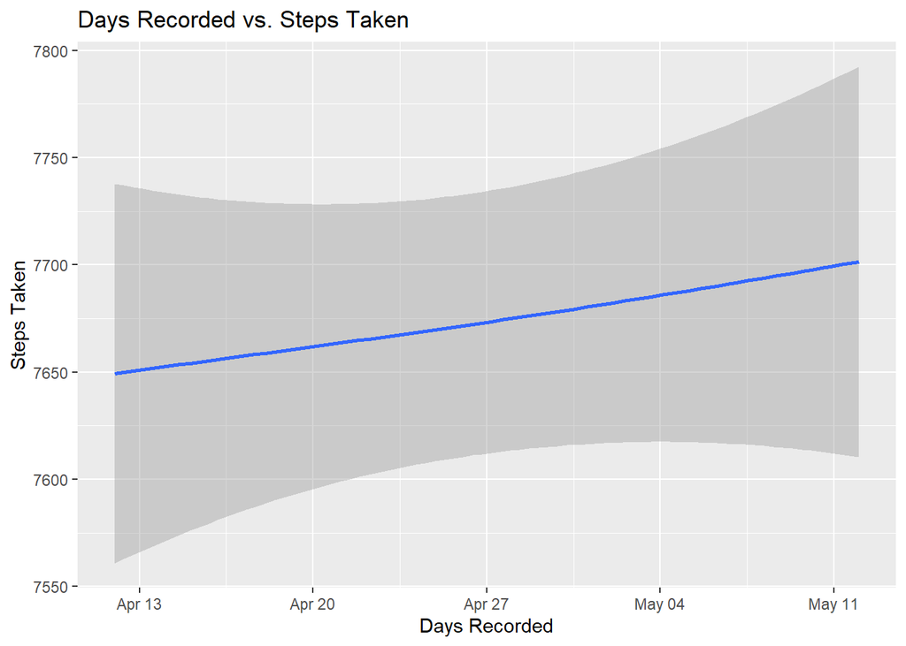

```r
# This graph shows the **rise** of the users steps over time

ggplot(record_activity, aes(x = ActivityDate, y = StepTotal)) +
  geom_smooth() +
  labs(x = "Days Recorded", y = "Steps Taken", title = "Days Recorded vs. Steps Taken")
```

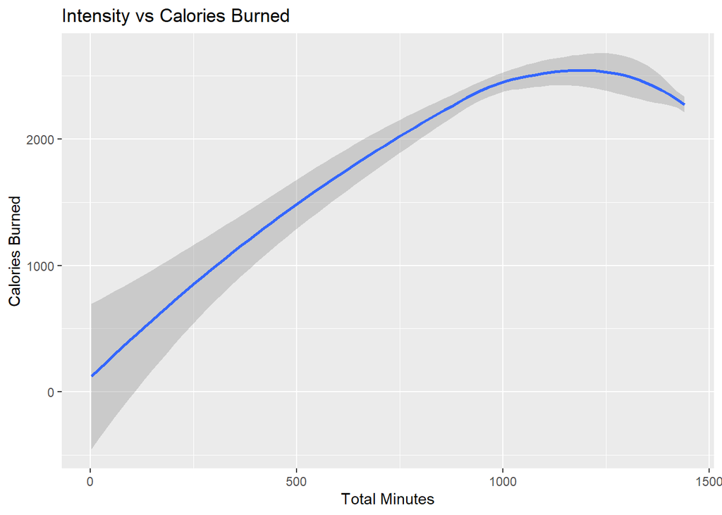

```r
# This graph shows the correlation between *longer exercise* leading to *more calories burned*

ggplot(total_intensities, aes(x = TotalMinutes, y = Calories))+
  geom_smooth()+
  labs(x = "Total Minutes", y = "Calories Burned", title = "Intensity vs Calories Burned")
```

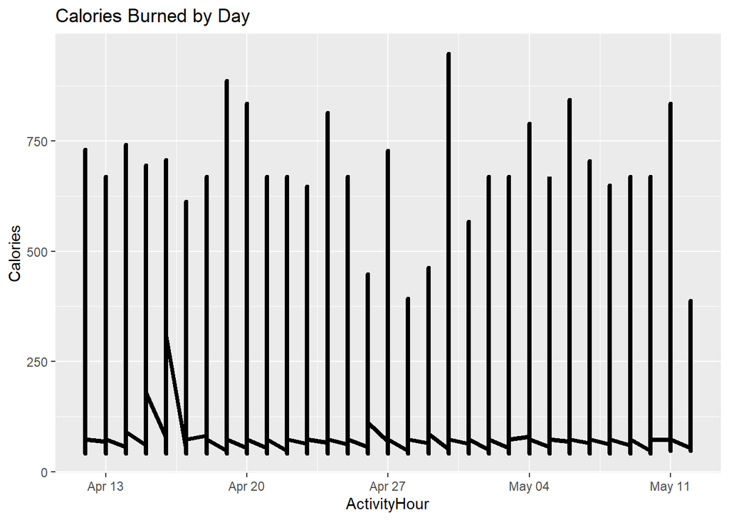

```r
# This graph shows the amount of *calories burned hourly each day* between all the participants

ggplot(data = hourly_Calories, aes(x = ActivityHour, y = Calories))+
  geom_line(size = 1.5)+
  labs(title = "Calories Burned by Day")
```

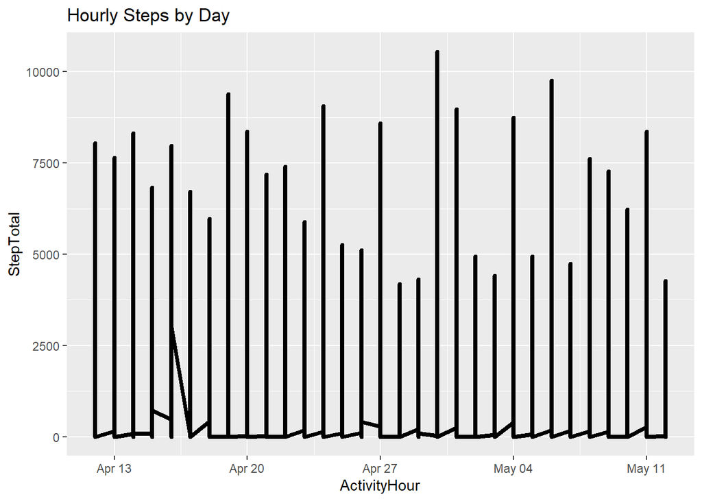

```r
# Shows the amount of *steps taken hourly each day* between all the participants

ggplot(data = hourly_steps, aes(x = ActivityHour, y = StepTotal))+
  geom_line(size = 1.5)+
  labs(title = "Hourly Steps by Day")
```

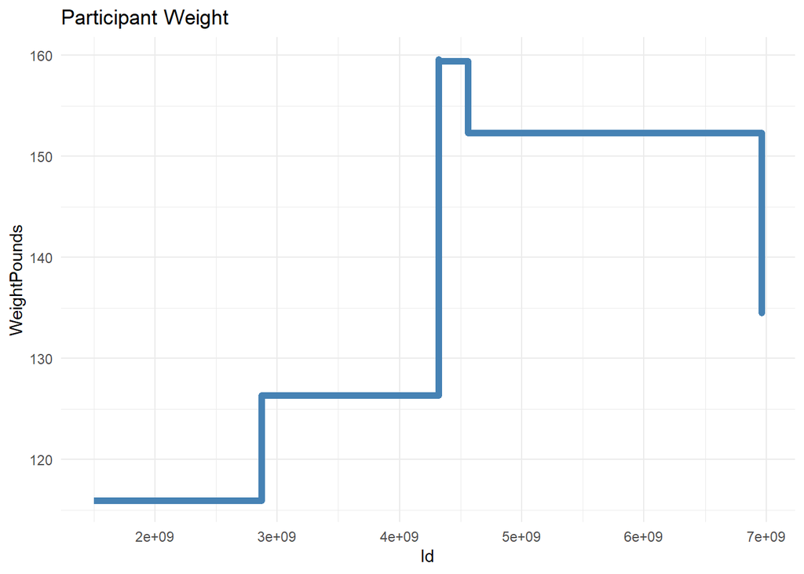

```r
# This graph shows the *participants weight from all of the values that were TRUE*

ggplot(data = weight_info, aes(x = Id, y = WeightPounds)) +
  geom_step(size = 2, color = "steelblue") +
  labs(title = "Participant Weight") +
  theme_minimal()
```

[figure not shown]

```r
# Visualizes the *weight averages for each day recorded*

ggplot(data = weight_summary, aes(x = Date, y = AverageWeight)) +
  geom_col(fill = "steelblue") +
  labs(title = "Average Weight by Day") +
  scale_x_date(date_labels = "%b %d, %Y", date_breaks = "1 week")
```

# **Act**

## **Conclusion**

Overall, I think Bellabeat has a great opportunity to innovate and add helpful and informative features to the app to help retain user traffic on the app so they can help reach their goals, as well as learning and helping others along the way by including an interactive interface to the app. With the Fitness tracker market contentiously growing with large growth rate potential in the future as well, there are many ways *Bellabeat* can take advantage of this opportunity to innovate by being unique compared to other competitors. As *Bellabeat* focuses on innovation they can also focus heavily on marketing to reach a larger audience of consumers that highlights the importance using the *app* to help reach personal goals and to help others along the way.